# Implementation of Multiclass Perceptron

Author: Anil Gurbuz

Last Updated: 12 Apr 2019

Perceptron is the building block of neural networks. Every node in a NN architecture is a single perceptron and it can be used for binary classification by forwarding the output of linear predictors $\sum \vec{w}\vec{x}^\top$ to an activation function which would map this summation to class probability between [0,1].

In this notebook, I will implement multiclass perceptron which could be done using several binary discriminant functions.

I will be using 2 approaches to combine several binary classifiers to create a multi-class decision boundary.

#### One For each Class

One way to step over ambigious region is using K number of binary classifiers each representing one class. This way during training each classifier learns assigning higher prob for a single class and final class predictions for each training/test point is decided by selecting the classifier that assigned highest probability to the test/train example. One advantage of this approach is capability of dividing the predictor space without creating any ambigious region.

```r
# Load libraries
library(ggplot2)
library(reshape2)
options(warn=-1)
options(repr.plot.width=6, repr.plot.height=4)

# Load datasets
train = read.csv('train.csv')
test = read.csv('test.csv')

# create training and testing datasets:
train.data = train[,-5]
train.label = train[,5]
test.data = test[,-5]
test.label = test[,5]

# Scale data
train.data=scale(train.data)
test.data=scale(test.data)

train.len = nrow(train)
test.len = nrow(test)
```

## One Perceptron for each Class

```r
Phi <- as.matrix(cbind(1, train.data)) # add a column of 1 to training data
eta <- 0.1 # Learning rate
epsilon <- 0.001 # Stoping criterion
tau.max <- 1000 # Maximum number of iterations
T <- train.label # rename just for conviniance

W.1 <- matrix(,nrow=tau.max, ncol=ncol(Phi)) # Empty Weight vector
W.2 <- matrix(,nrow=tau.max, ncol=ncol(Phi)) # Empty Weight vector
W.3 <- matrix(,nrow=tau.max, ncol=ncol(Phi)) # Empty Weight vector

W.1[1,] <- runif(ncol(Phi)) # Random initial values for weight vector
W.2[1,] <- runif(ncol(Phi)) # Random initial values for weight vector
W.3[1,] <- runif(ncol(Phi)) # Random initial values for weight vector

error = matrix(,nrow=tau.max, ncol=1) # To store error values

tau <- 1 # iteration counter
terminate <- FALSE # termination status

while(!terminate){

    # Shuffle the data
    train.index <- sample(1:train.len, replace = FALSE)
    Phi <- Phi[train.index,]
    T <- T[train.index]

    #For each point...
    for (i in train.index){

        # Check the termination creteria
        if (tau == tau.max) {break}

        # Calculate the predictions of current models for current point
        val1= W.1[tau,]%*%Phi[i,]
        val2= W.2[tau,]%*%Phi[i,]
        val3= W.3[tau,]%*%Phi[i,]
        max = max(val1,val2,val3)


        # If prediction doesn't match with label...
        if (val1==max && T[i]!="C1"|val2==max && T[i]!="C2"|val3==max && T[i] !="C3"){

            # Increase iteration counter
            tau = tau +1

            # Update coefficients
            if (T[i]=='C1' && max==val2){
                W.1[tau,] = W.1[tau-1,] + eta*Phi[i,]
                W.2[tau,] = W.2[tau-1,] - eta*Phi[i,]
                W.3[tau,] = W.3[tau-1,]

            }else if (T[i]=='C1' && max==val3){
                W.1[tau,] = W.1[tau-1,] + eta*Phi[i,]
                W.2[tau,] = W.2[tau-1,]
                W.3[tau,] = W.3[tau-1,] - eta*Phi[i,]

            }else if (T[i]=='C2' && max==val1){
                W.1[tau,] = W.1[tau-1,] - eta*Phi[i,]
                W.2[tau,] = W.2[tau-1,] + eta*Phi[i,]
                W.3[tau,] = W.3[tau-1,]
            }else if (T[i]=='C2' && max==val3){
                W.1[tau,] = W.1[tau-1,]
                W.2[tau,] = W.2[tau-1,] + eta*Phi[i,]
                W.3[tau,] = W.3[tau-1,] - eta*Phi[i,]

            }else if (T[i]=='C3' && max==val2){
                W.1[tau,] = W.1[tau-1,]
                W.2[tau,] = W.2[tau-1,] - eta*Phi[i,]
                W.3[tau,] = W.3[tau-1,] + eta*Phi[i,]

            }else if (T[i]=='C3' && max==val1){
                W.1[tau,] = W.1[tau-1,] - eta*Phi[i,]
                W.2[tau,] = W.2[tau-1,]
                W.3[tau,] = W.3[tau-1,] + eta*Phi[i,]

            }

        }
    }

    # Calculate predictions for current models and the error value
    predictions=as.data.frame(cbind(t(W.1[tau,]%*%t(Phi)),t(W.2[tau,]%*%t(Phi)),t(W.3[tau,]%*%t(Phi))))
    for (row in 1:nrow(predictions)){
        predictions[row,'pred']=paste('C', which.max(predictions[row,]),sep = '')
    }
    error.percentage=1-(sum(predictions[,'pred']==T)/nrow(predictions))


    # recalculate termination conditions
    terminate <- (tau >= tau.max | (error.percentage<=epsilon))
    }

# Done, trim the dataframes
W.1 <- W.1[1:tau,]
W.2 <- W.2[1:tau,]
W.3 <- W.3[1:tau,]
```

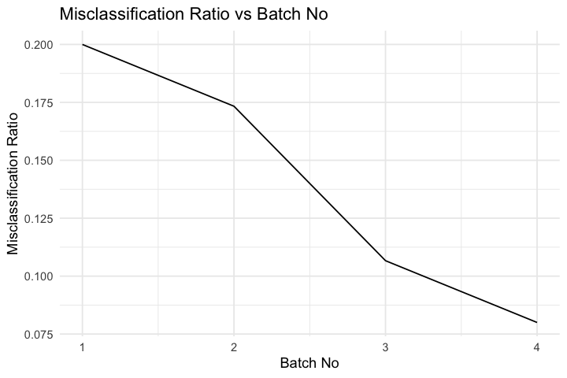

```r
# test data appropriate for multiplication with model parameters
test.Phi <- as.matrix(cbind(1, test.data))

# Data frame to store error values and corresponding batch
error.percentage=data.frame(0,ncol=2)
colnames(error.percentage)=c('Batch','Error Percentage')

# Initilise batch.no
batch.no=0

# For each batch...
for (batch in seq(5,nrow(W.1),5)){

    # Calculate batch No
    batch.no= batch.no + 1

    # Make predictions on entire test data using each W
    predictions=as.data.frame(cbind(t(W.1[batch,]%*%t(test.Phi)),t(W.2[batch,]%*%t(test.Phi)),t(W.3[batch,]%*%t(test.Phi))))

    # Classify predicted points
    for (row in 1:nrow(predictions)){
        predictions[row,'pred']=paste('C', which.max(predictions[row,]),sep = '')
    }

    # Store Batch no and Ratio of missclassifications
    error.percentage[batch.no,1]=batch.no
    error.percentage[batch.no,2]=1-(sum(predictions[,'pred']==train.label)/nrow(predictions))

}

# Plot Batch no vs Missclassification Ratio
error.m=melt(error.percentage, id='Batch')
ggplot(data=error.m, aes(Batch,value)) +
labs(y='Misclassification Ratio', x='Batch No') +
ggtitle('Misclassification Ratio vs Batch No') +
geom_line() + theme_minimal()
```

## One vs. One Approach

```r
# Define binary classifier to use for all combination of classes in the next steps
binary <- function(train.data, train.label, train.len, eta, epsilon, tau.max){

    Phi <- as.matrix(cbind(1, train.data)) # add a column of 1 as phi_0

    T <- train.label # rename just for conviniance

    W <- matrix(,nrow=tau.max, ncol=ncol(Phi)) # Empty Weight vector
    W[1,] <- runif(ncol(Phi)) # Random initial values for weight vector

    error.trace <- matrix(0,nrow=tau.max, ncol=1) # Placeholder for errors
    error.trace[1] <- sum((Phi%*%W[1,])*T<0)/train.len*100 # record error for initial weights

    tau <- 1 # iteration counter
    terminate <- FALSE # termination status


    while(!terminate){
    # resuffling train data and associated labels:
    train.index <- sample(1:train.len, replace = FALSE)
    Phi <- Phi[train.index,]
    T <- T[train.index]

    for (i in 1:train.len){
        if (tau == tau.max) {break}

        # look for missclassified samples
        if ((W[tau,]%*%Phi[i,])*T[i]<0){

            # update tau counter
            tau <- tau +1

            # update the weights
            W[tau,] <- W[tau-1,] + eta * Phi[i,] * T[i]

            # update the records
            error.trace[tau] <- sum((Phi%*%W[tau,])*T<0)/train.len*100
        }

    }

    # decrease eta:
    eta = eta * 0.99
    # recalculate termination conditions
    terminate <- (tau >= tau.max | sum((Phi%*%W[tau,])*T<0)/train.len <= epsilon )

}

    W <- W[1:tau,] # cut the empty part of the matrix (when the loop stops before tau == tau.max)

    # Return final parameters
    return(W[tau,])


}
```

```r
eta <- 0.1 # Learning rate
epsilon <- 0.001 # Stoping criterion
tau.max <- 100 # Maximum number of iterations

# Index values of each class labels
indx.c1=which(train.label=='C1')
indx.c2=which(train.label=='C2')
indx.c3=which(train.label=='C3')

# Because the labels are sorted we can use known indexes of classes.
# For example to catch C1 and C2 1:50 is enough because C1 indexes = 1:25
# C2 indexes = 26:50 , C3 indexes = 51:75

# C1 -> +1, C2 -> -1
train.data.c1.c2 = train.data[1:50,]
train.label.c1.c2 = rep(1,50)
train.label.c1.c2[26:50]=-1
train.len.c1.c2=50


# C1 -> +1, C3 -> -1
train.data.c1.c3 = train.data[c(1:25,51:75),]
train.label.c1.c3 = rep(1,50)
train.label.c1.c3[26:50]=-1
train.len.c1.c3=50

# C2 -> +1, C3 -> -1
train.data.c2.c3 = train.data[26:75,]
train.label.c2.c3 = rep(1,50)
train.label.c2.c3[26:50]=-1
train.len.c2.c3=50

# Train a binary classifier for all combinations of classes
w.c1.c2=binary(train.data.c1.c2, train.label.c1.c2, train.len.c1.c2, eta, epsilon, tau.max)
w.c1.c3=binary(train.data.c1.c3, train.label.c1.c3, train.len.c1.c3, eta, epsilon, tau.max)
w.c2.c3=binary(train.data.c2.c3, train.label.c2.c3, train.len.c2.c3, eta, epsilon, tau.max)

# test data appropriate for multiplication with model parameters
Phi.test=as.matrix(cbind(1, test.data))

# Make predictions on entire test data using all of the classifiers
pred.c1.c2 =Phi.test %*% w.c1.c2
pred.c1.c3 =Phi.test %*% w.c1.c3
pred.c2.c3 =Phi.test %*% w.c2.c3

# postive prediction -> C1  , negative prediction -> C2
pred.c1.c2 = as.data.frame(cbind(pred.c1.c2,0))
colnames(pred.c1.c2) = c("Value",'C1-C2')
pred.c1.c2[pred.c1.c2['Value']>=0,2] = 'C1'
pred.c1.c2[pred.c1.c2['Value']<0,2] = 'C2'
pred.c1.c2=pred.c1.c2['C1-C2']

# postive prediction -> C1  , negative prediction -> C3
pred.c1.c3 = as.data.frame(cbind(pred.c1.c3,0))
colnames(pred.c1.c3) = c("Value",'C1-C3')
pred.c1.c3[pred.c1.c3['Value']>=0,2] = 'C1'
pred.c1.c3[pred.c1.c3['Value']<0,2] = 'C3'
pred.c1.c3=pred.c1.c3['C1-C3']

# postive prediction -> C2  , negative prediction -> C3
pred.c2.c3 = as.data.frame(cbind(pred.c2.c3,0))
colnames(pred.c2.c3) = c("Value",'C2-C3')
pred.c2.c3[pred.c2.c3['Value']>=0,2] = 'C2'
pred.c2.c3[pred.c2.c3['Value']<0,2] = 'C3'
pred.c2.c3=pred.c2.c3['C2-C3']

# Reshape for vote counting
predictions=cbind(pred.c1.c2,pred.c1.c3,pred.c2.c3)

# Matrix to store classification of all points after vote counting
last_predictions=matrix(nrow=nrow(test.data))

# Calculate the votings for each point to classify
for (i in 1:nrow(predictions)){
    if (predictions[i,1] =='C1' && predictions[i,2]== 'C1'){
        last_predictions[i]='C1'
    }else if (predictions[i,1] =='C2' && predictions[i,3]== 'C2'){
        last_predictions[i]='C2'
    }else if(predictions[i,2] =='C3' && predictions[i,3]== 'C3'){
        last_predictions[i]='C3'
    }else {last_predictions[i]='Confusion Event'}
}

# Print number of Confusion events
cat(sprintf('Number of Confusion Events :%i',sum(last_predictions=='Confusion Event')))
```

```
Number of Confusion Events :2
```

### Ambigious region in predictor space due to "1 vs 1 Approach" and confusion events.

In the above data, there are 3 different target classes which requires to create totally 3*2/3=3 different classifier corresponding one for each pair of the classes. Partitioning of this 4-D(x1,x2,x3,x4) training space space by 3 different 3-D spaces creates an ambigious part. If a point's classes are predicted as C1, C2 and C3 by these 3 different classifiers, this point is located in ambigious part of the partitioned 4-D space and called confusion event.

[figure not shown]